# R Notebook for Nonparametric Final Project

Xiaotong Lin, Yiqiao Yin

# 1 Introduction

Identifying variables that are useful in prediction and in inference are both important in today’s statistical learning and practice, especially for current and future big data problems. As data sets grow unwieldy, searching for important and predictive variables, or clusters of variables that are responsible for important trends or patterns, becomes more and more challenging and essential. However, the popular statistical methods that have served us well for many decades, dealing with numerous problems, mahy no longer be adequate for complicated problems arising from current data sets. For example, recent discoveries of significant variants using traditional statistical tests in GWAS studies have not been accompanied with gains in prediction, or to gain better understanding of genetic functions. This phenomenon is pervasive across different types of data and problems, as well as different sample sizes, posing a general question: why don’t highly statistically significant variableslead to good predictors nor regressors? This type of basic questions, used to be worked well by familiar methods, requires to give second thoughts and reevaluations.

The purpose of this project is to investigate the performance comparison between non-parametric and parametric classification method.

Back to top

# 2 Main Objectives

We are interested the performance of using non-parametric and parametric methods. Moreover, in which way do they differ from each other?

Back to top

## 2.1 Aritificial Data

This section introduces experimental design. We generate artificial data set from (a) Bernoulli Distribution, (b) Normal Distribution, and (c) random complex distribution. Each artificial data is also defined by number of observations, $n$, and number of parameters, $p$.

Back to top

## 2.2 Simulation: Experiment Design

Each artificial data from (a), (b), to (c) we test the following sequence of algorithms. First, we approach the data directly with common classification method such as Logistic, Random Forest, SVM, and Neural Network. Then we construct features using the same data with non-parametric technique such as Principle Component and K-Means.

Back to top

## 2.3 Simulation: Results

```r
# Let us load the sciprt of all defined functions
path <- "C:/Users/eagle/OneDrive/STATS GR5222 - Nonparametric Statistics/5. Project/"
source(paste0(path,"scripts/definition_of_functions.R"))
```

Back to top

## 2.4 Artificial Example 1: Bernoulli

First, let us create an artificial data set with a certain number of observations, $n$, and a certain number of parameters, $p$. That is, we create $X_i \sim \text{Bernoulli}(n,1/2)$. We define response, $Y$, to be
$$Y = X_1 + X_2 (\text{mod} 2)$$
Hence, the correct prediction rate for this underlying model is 100%.

By allowing $n$ and $p$ to take values in $[50,100,1000]$, we have 9 artificial data sets with different pairs of $(n,p)$. Each pair of $(n,p)$ we test the following algorithms:

- Directly apply Logistic, Random Forest, SVM, and Neural Network;
- Use Principle Components to construct features and then use Logistic, Random Forest, SVM, and Neural Network on new features;
- Use K-Means to construct features and then use Logistic, Random Forest, SVM, and Neural Network on new features.

Back to top

#### 2.4.0.1 Performance Comparison

Last we present the performance for all algorithms using *cloud()* function so that we the following performance visualization.

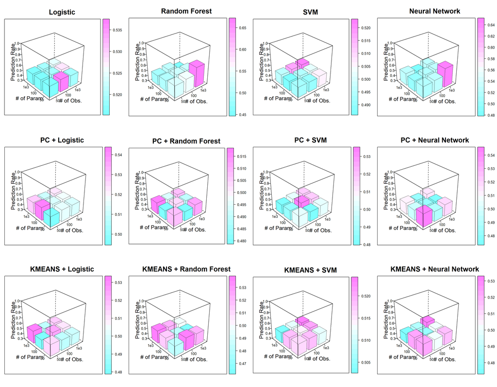

Back to top

## 2.5 Artificial Example 2: Normal

Next, let us create an artificial data set with a certain number of observations, $n$, and a certain number of parameters, $p$. That is, we create $X_i \sim \text{N}(0,1)$. We define response, $Y$, to be
$$Y = 1 \text{ if } \sum_{i=1}^{10}X_i > \frac{1}{n}\sum_{i=1}^{10}X_i; Y = 0 \text{ if } \sum_{i=1}^{10}X_i \le \frac{1}{n}\sum_{i=1}^{10}X_i$$
Hence, the correct prediction rate for this underlying model is 100%.

By allowing $n$ and $p$ to take values in $[100,300,1000]$, we have 9 artificial data sets with different pairs of $(n,p)$. Each pair of $(n,p)$ we test the following algorithms:

- Directly apply Logistic, Random Forest, SVM, and Neural Network;
- Use Principle Components to construct features and then use Logistic, Random Forest, SVM, and Neural Network on new features;
- Use K-Means to construct features and then use Logistic, Random Forest, SVM, and Neural Network on new features.

Back to top

#### 2.5.0.1 Performance Comparison

Last we present the performance for all algorithms using *cloud()* function so that we the following performance visualization.

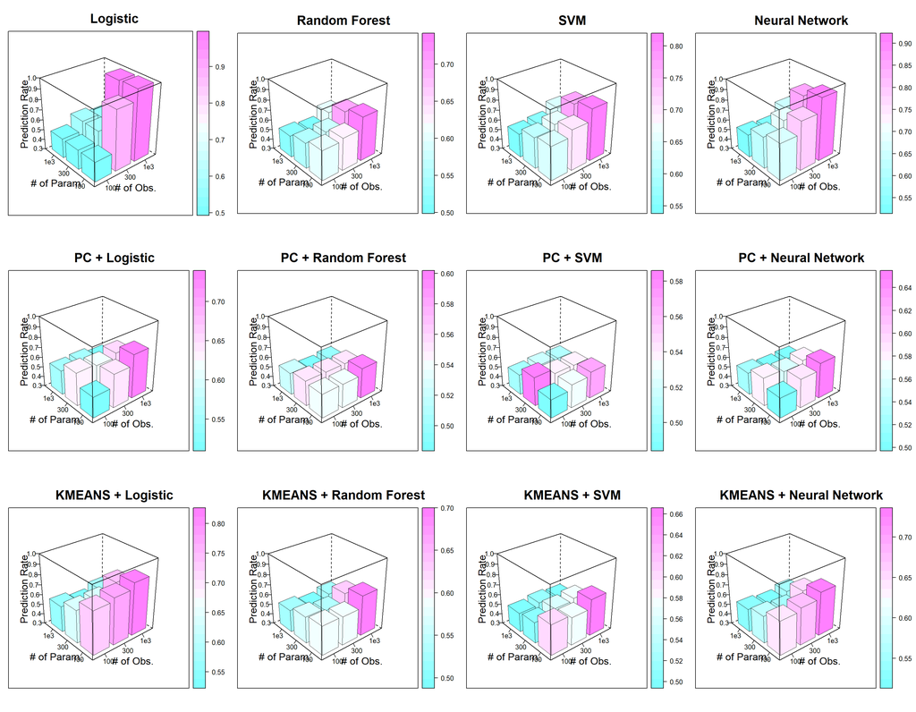

Back to top

## 2.6 Artificial Example 3: Complex

Thirdly, let us create an artificial data set with a certain number of observations, $n$, and a certain number of parameters, $p$. That is, we create $X_i \sim \text{N}(0,1)$. We define $T = (\sum_{i=1}^{3}X_i)+X_1*X_2+X_4^2+X_5*X_5*X_7+\exp(X_8)$. Then we define response, $Y$, to be
$$Y = 1 \text{ if } T > \frac{1}{n} T; Y = 0 \text{ if } T \le \frac{1}{n} T$$
Hence, the correct prediction rate for this underlying model is 100%.

By allowing $n$ and $p$ to take values in $[100,300,1000]$, we have 9 artificial data sets with different pairs of $(n,p)$. Each pair of $(n,p)$ we test the following algorithms:

- Directly apply Logistic, Random Forest, SVM, and Neural Network;
- Use Principle Components to construct features and then use Logistic, Random Forest, SVM, and Neural Network on new features;
- Use K-Means to construct features and then use Logistic, Random Forest, SVM, and Neural Network on new features.

Back to top

#### 2.6.0.1 Performance Comparison

Last we present the performance for all algorithms using *cloud()* function so that we the following performance visualization.

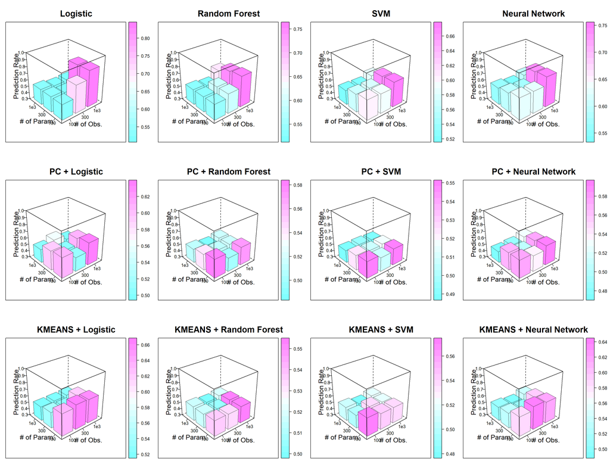

Back to top